# R Notebook

## Running individual phenotype.

```r
# CUDA_VISIBLE_DEVICES=3 python train.py  --data_dir  ~/project/deeplearning/icb/data/tcga/tf/binarize/datasets_tsne_list.txt --model_dir ~/project/deeplearning/icb/data/tcga/tf/binarize/.  --tensorboard_prefix surv_noaug_bin_ --hyper_param "params.add_noise=0"
#
#
col.names = colnames(fread("~/project/deeplearning/icb/data/tcga/tf/binarize/dataset_val.txt",nrows = 1))
start = 4001 + 244 -2
pheno.all.inx = 4001 + 244:438
pheno.type = c(rep("continuous", 400-244 +1), rep("binary",430-401+1), rep( "survival",438-431+1))
pheno.next = start+1
pheno.last.index = pheno.all.inx[length(pheno.all.inx)]
commands = list()
cuda.id = 0
while(pheno.next < pheno.last.index){
    label.curr = paste0("Pheno_",pheno.next, "_", col.names[pheno.next], "_")
    if (pheno.type[pheno.next - start] == "continuous"){
        pheno.str=sprintf("continuous_phenotype_indices=[%d]", pheno.next-2)
        pheno.next = pheno.next + 1
    }else if (pheno.type[pheno.next - start] == "binary"){
        pheno.str=sprintf("binary_phenotype_indices=[%d]", pheno.next-2)
        pheno.next = pheno.next + 1
    }else if(pheno.type[pheno.next - start]=="survival"){
        pheno.str=sprintf("survival_indices=[%d, %d]", pheno.next-2, pheno.next-2+1)
        pheno.next = pheno.next + 2
    }
    commands[[label.curr]] = sprintf("CUDA_VISIBLE_DEVICES=%d python train.py  --data_dir  ~/project/deeplearning/icb/data/tcga/tf/binarize/datasets_tsne_list.txt --model_dir ~/project/deeplearning/icb/data/tcga/tf/binarize/.  --tensorboard_prefix %s --hyper_param \"params.%s\"",cuda.id, label.curr, pheno.str)
    cuda.id = (cuda.id +1) %% 4

}


library(parallel)
# Using fork()
mc.cores = 16
out = list()
for (ii in seq(ceiling(length(commands)/mc.cores))) {
    last.task.in.itr = min(length(commands), mc.cores * (ii))
    tasks.curr = commands[(mc.cores * (ii-1) +1 ): last.task.in.itr]
    print(sprintf("running commands %d", last.task.in.itr))
    # print(tasks.curr)
    out[[ii]] <- mclapply(tasks.curr, function(tt) system(c(unlist(tt)),intern =  T),
                          mc.cores = mc.cores)
    # out <- mclapply(tasks.curr, function(tt) c(unlist(tt)),
    # mc.cores = mc.cores, mc.cleanup=TRUE)
}
```

```r
create.deepImmune.dataset <- function( expression.file, followup.file, genes.curr) {
    aa = fread(expression.file)
    bb = fread(followup.file)
    genes.inx = match(genes.curr, aa$Symbol)
    patient.curr = intersect(bb$Patient, colnames(aa))
    patient.inx = match(patient.curr, colnames(aa))
    exp.mat = t(aa[genes.inx, patient.inx, with=F])
    pheno.mat =  bb[match(patient.curr, Patient), -1,with=F]
    list(sample=patient.curr, exp=exp.mat, pheno=pheno.mat)
}

create.deepImmune.input <- function(output.dir, expression.file,  genes.curr) {
    aa = fread(expression.file)
    genes.inx = match(genes.curr, aa$Symbol)
    exp.mat = as.matrix(t(aa[genes.inx,-1,with=F]) )
    colnames(exp.mat) = genes.curr
    exp.mat
}
```

```r
expression.file="~/liulab_home/data/ssgsea/xiaoman/icb/expression/Gide2019_PD1+CTLA4_Melanoma_RNASeq"
followup.file="~/liulab_home/data/ssgsea/xiaoman/icb/follow_up/Gide2019_PD1+CTLA4_Melanoma_RNASeq"
dataset.curr = create.deepImmune.dataset(expression.file = expression.file, followup.file = followup.file, genes.curr=genes.analyzed)
```

```r
expression.files = list.files(path = "~/liulab_home/data/ssgsea/xiaoman/icb/expression/", full.names = T)
load("~/project/deeplearning/icb/data/tcga/tf/genes.analyzed.RData")
dataset.exp.only =  sapply( expression.files, function(expression.file) create.deepImmune.input(expression.file = expression.file,  genes.curr=genes.analyzed), USE.NAMES = T)
dataset.name = sapply(expression.files, basename)
expression.dataset.patinet.name = lapply(dataset.exp.only, rownames)
names(expression.dataset.patinet.name) = dataset.name
all.expression = do.call(rbind, dataset.exp.only)
dataset.label = sapply(seq(length(dataset.exp.only)), function(tt) rep(tt, nrow(dataset.exp.only[[tt]])))
```

```r
cancertype = unlist(dataset.label)
all.icb.dataset = data.table(cbind(cancertype, all.expression))
output.dir = "~/project/deeplearning/icb/data/icb/tf"
write.dataset(output.dir = output.dir, dataset = all.icb.dataset, sample.name = rownames(all.expression))
file.copy("~/project/deeplearning/icb/data/tcga/tf/binarize/params.json", output.dir)
file.copy("~/project/deeplearning/icb/data/tcga/tf/binarize/datasets_tsne_list.txt", output.dir)
file.copy("~/project/deeplearning/icb/data/tcga/tf/binarize/datasets_test_list.txt", output.dir)
```

## running the icb data for each phenotype

```r
# python evaluate.py  --data_dir  %s/datasets_test_list.txt --model_dir %s/.  --restore_file %s/last.pth.tar  --output_dir $PATH/all.icb/
#
#
model_dirs =list.files(path = "/homes6/asahu/project/deeplearning/icb/data/tcga/tf/binarize/./tensorboardLog/", full.names = T, pattern = "^Pheno_")
data_dir = "/homes6/asahu/project/deeplearning/icb/data/icb/tf/"
for (model_dir in model_dirs) {
    label = basename(model_dir)
    hyper.params = readLines(paste0(model_dir,"/","hyper_param.txt"),warn=F)
    command = sprintf("python evaluate.py  --data_dir  %s/datasets_test_list.txt --model_dir %s/.  --restore_file %s/best.pth.tar  --output_dir %s/all.icb/ --hyper_param %s", data_dir, model_dir, model_dir, model_dir, hyper.params)
    system(command,intern =  T)
}
```

```r
## reading result for each phenotype
icb.predicted = list()
for (model_dir in model_dirs) {
    label = basename(model_dir)
    outp = fread(sprintf("%s/all.icb/val_0_prediction.csv", model_dir))
    icb.predicted[[label]] = outp[,seq(ncol(outp)-4, ncol(outp)),with=F]
}
phenotypes.predicted = do.call( cbind, lapply(icb.predicted, function(tt) tt[[1]]))
embedding.predicted = do.call( cbind, lapply(icb.predicted, function(tt) as.matrix(tt[,2:5,with=F])))
```

## evaluate ICB response

```r
## First only using immune phenotypes
## Then use emebedding
## both response information and survival info.


## match ICB patients for which response information is there
##
followups = sapply(list.files(path = "~/liulab_home/data/ssgsea/xiaoman/icb/follow_up/", full.names = T), fread, USE.NAMES = TRUE)
```

[output not shown]

```r
dataset.name = sapply(list.files(path = "~/liulab_home/data/ssgsea/xiaoman/icb/expression/", full.names = T), basename)
meta.info.dt = do.call(rbind, lapply(dataset.name, function(tt) data.table(Patient=expression.dataset.patinet.name[[tt]], names=tt)))
meta.info.dt$inx = seq(nrow(meta.info.dt))
meta.info.dt[,label:=paste(Patient, names)]
names(followups) = sapply(names(followups), basename)
sapply(followups, function(tt) setnames(tt, 1, "Patient"))
```

| Patient | Response |
| --- | --- |
| P5 | 1 |
| P7 | 0 |
| P8 | 0 |
| P9 | 0 |
| P10 | 1 |
| P18 | 0 |
| P19 | 0 |
| P22 | 1 |
| P23 | 0 |
| P25 | 0 |

[output cut: 6 more lines]

| Patient | Response |
| --- | --- |
| P2 | 0 |
| P3 | 0 |
| P4 | 0 |
| P6 | 1 |
| P6 | 1 |
| P8 | 1 |
| P9 | 1 |
| P16 | 0 |
| P18 | 0 |
| P24 | 1 |

[output cut: 5 more lines]

```
$`Gide2019_PD1+CTLA4_Melanoma_RNASeq`
```

| Patient | OS | OS.Event | PFS | PFS.Event | Age | Gender | Response |
| --- | --- | --- | --- | --- | --- | --- | --- |
| P8 | 156 | 1 | 81 | 1 | 56 | 0 | 0 |
| P10 | 221 | 0 | 82 | 1 | 62 | 0 | 0 |
| P13 | 691 | 0 | 123 | 1 | 47 | 1 | 0 |
| P14 | 660 | 1 | 152 | 1 | 57 | 0 | 0 |
| P15 | 558 | 0 | 168 | 1 | 39 | 1 | 1 |
| P19 | 538 | 0 | 386 | 1 | 57 | 0 | 0 |
| P24 | 518 | 1 | 518 | 0 | 67 | 1 | 0 |
| P27 | 553 | 0 | 553 | 0 | 33 | 0 | 1 |
| P33 | 623 | 0 | 623 | 0 | 51 | 0 | 1 |
| P35 | 637 | 0 | 637 | 0 | 74 | 1 | 1 |

[output cut: 7 more lines]

| Patient | OS | OS.Event | PFS | PFS.Event | Age | Gender | Response |
| --- | --- | --- | --- | --- | --- | --- | --- |
| P2 | 59 | 1 | 23 | 1 | 50 | 0 | 0 |
| P3 | 22 | 1 | 23 | 1 | 84 | 0 | 0 |
| P5 | 94 | 1 | 42 | 1 | 68 | 0 | 0 |
| P6 | 80 | 1 | 47 | 1 | 57 | 1 | 0 |
| P7 | 58 | 1 | 58 | 1 | 85 | 1 | 0 |
| P9 | 551 | 0 | 76 | 1 | 90 | 0 | 0 |
| P10 | 166 | 1 | 78 | 1 | 66 | 0 | 0 |
| P11 | 199 | 1 | 80 | 1 | 52 | 0 | 0 |
| P12 | 96 | 1 | 82 | 1 | 69 | 0 | 0 |
| P13 | 993 | 1 | 83 | 1 | 58 | 0 | 0 |

[output cut: 27 more lines]

| Patient | OS | OS.Event | RECIST | Age | Gender | Stage | MAPKi | Response |
| --- | --- | --- | --- | --- | --- | --- | --- | --- |
| Pt1 | 607 | 1 | 0 | 66 | 1 | 2 | 0 | 0 |
| Pt2 | 927 | 0 | 2 | 55 | 0 | 3 | 0 | 1 |
| Pt3 | 691 | 1 | 2 | 58 | 0 | 3 | 0 | 1 |
| Pt4 | 948 | 0 | 2 | 62 | 0 | 3 | 1 | 1 |
| Pt5 | 439 | 0 | 2 | 61 | 0 | 3 | 0 | 1 |
| Pt6 | 882 | 0 | 2 | 51 | 0 | 3 | 1 | 1 |
| Pt7 | 662 | 1 | 0 | 55 | 1 | 3 | 0 | 0 |
| Pt8 | NA | 0 | 3 | 69 | 0 | 1 | 0 | 1 |
| Pt9 | 1054 | 0 | 3 | 68 | 0 | 0 | 0 | 1 |
| Pt10 | 387 | 0 | 0 | 60 | 0 | 1 | 1 | 0 |

[output cut: 28 more lines]

| Patient | Response |
| --- | --- |
| PB-16-045 | 1 |
| PB-16-068 | 1 |
| PB-16-031 | 1 |
| PB-16-005 | 1 |
| PB-16-010 | 1 |
| PB-16-013 | 1 |
| PB-16-019 | 1 |
| PB-16-020 | 1 |
| PB-16-021 | 1 |
| PB-16-038 | 1 |

[output cut: 51 more lines]

| Patient | OS | OS.Event | PFS | PFS.Event | Gender | mStage | Response |
| --- | --- | --- | --- | --- | --- | --- | --- |
| Patient102 | 785 | 0 | 176 | 1 | 0 | 3 | 1 |
| Patient105 | 521 | 1 | 378 | 0 | 1 | 3 | 1 |
| Patient106 | 780 | 0 | 780 | 0 | 1 | 3 | 1 |
| Patient107 | 47 | 1 | 47 | 1 | 0 | 3 | 1 |
| Patient108 | 165 | 1 | 77 | 1 | 0 | 3 | 0 |
| Patient112 | 521 | 1 | 91 | 1 | 1 | 3 | 0 |
| Patient116 | 118 | 1 | 64 | 1 | 1 | 3 | 0 |
| Patient125 | 978 | 0 | 978 | 0 | 0 | 3 | 1 |
| Patient126 | 992 | 0 | 742 | 1 | 0 | 3 | 1 |
| Patient127 | 866 | 0 | 866 | 0 | 0 | 3 | 1 |

[output cut: 64 more lines]

| Patient | OS | OS.Event | PFS | PFS.Event | Gender | mStage | Response |
| --- | --- | --- | --- | --- | --- | --- | --- |
| Patient1 | 283 | 1 | 93 | 1 | 1 | 3 | 0 |
| Patient10 | 1139 | 1 | 169 | 1 | 1 | 3 | 1 |
| Patient100 | 938 | 1 | 922 | 0 | 1 | 3 | 1 |
| Patient11 | 160 | 1 | 85 | 1 | 1 | 3 | 0 |
| Patient117 | 295 | 1 | 100 | 1 | 1 | 3 | 0 |
| Patient121 | 1306 | 0 | 1228 | 1 | 1 | 3 | 1 |
| Patient13 | 58 | 1 | 44 | 1 | 0 | 3 | 0 |
| Patient15 | 149 | 1 | 105 | 1 | 1 | 3 | 1 |
| Patient159 | 288 | 0 | 216 | 1 | 1 | 3 | 0 |
| Patient162 | 201 | 1 | 53 | 1 | 0 | 3 | 0 |

[output cut: 37 more lines]

| Patient | OS | OS.Event | Response | Neoantigen |
| --- | --- | --- | --- | --- |
| SAMf2ce197162ce | 1.5770021 | 1 | NA | 0.56862745 |
| SAM698d8d76b934 | 0.4271047 | 1 | NA | 1.01960784 |
| SAMc1b27bc16435 | 24.1806982 | 0 | 1 | 1.41176471 |
| SAM85e41e7f33f9 | 0.6242300 | 1 | NA | 1.25490196 |
| SAMf275eb859a39 | 24.4763860 | 0 | 1 | NA |
| SAM7f0d9cc7f001 | 4.6324435 | 1 | 0 | NA |
| SAM4305ab968b90 | 1.4127310 | 1 | 0 | 0.39215686 |
| SAMcf018fee2acd | 16.2299795 | 1 | 0 | NA |
| SAMb2f1d0e54ece | 11.4004107 | 1 | 1 | 0.86274510 |
| SAMcc4675f394a1 | 3.1211499 | 1 | 0 | NA |

[output cut: 338 more lines]

| Patient | Response |
| --- | --- |
| 05e004a1302c | 0 |
| 55cc6edfad7f | 1 |
| 053ea1347beb | 0 |
| b9ecc1c4a366 | 0 |
| c4519f8209ec | 0 |
| 100617625aa4 | 1 |
| cb57aea6138b | 0 |
| c889cb234bf4 | 0 |
| d8ed24f7631a | 0 |
| 3ec4d3fc8bd1 | 1 |

[output cut: 71 more lines]

| Patient | OS | OS.Event | PFS | PFS.Event | Response | RECIST | Age | Gender | First_line | Drug | PBRM1 |
| --- | --- | --- | --- | --- | --- | --- | --- | --- | --- | --- | --- |
| RCC_97 | 871 | 0 | 37 | 1 | 0.0 | 0 | 54 | 0 | 0 | nivolumab | 1 |
| RCC_52 | 995 | 0 | 246 | 1 | 1.0 | 1 | 63 | 1 | 1 | nivolumab | 1 |
| RCC_27 | 968 | 0 | 35 | 1 | 0.0 | 0 | 59 | 0 | 0 | nivolumab | 0 |
| RCC_119 | 773 | 0 | 414 | 1 | 1.0 | 2 | 72 | 0 | 0 | nivolumab | 1 |
| RCC_105 | 118 | 1 | 45 | 1 | 0.0 | 0 | 64 | 0 | 0 | nivolumab | 0 |
| RCC_39 | 306 | 1 | 37 | 1 | 0.0 | 0 | 72 | 0 | 0 | nivolumab | 0 |
| RCC_73 | 178 | 1 | 58 | 1 | 0.0 | 0 | 77 | 0 | 0 | nivolumab | 0 |
| RCC_50 | 982 | 0 | 86 | 1 | 1.0 | 1 | 63 | 1 | 1 | nivolumab | 1 |
| RCC_41 | 195 | 0 | 42 | 1 | 0.0 | 0 | 66 | 0 | 0 | nivolumab | 0 |
| RCC_18 | 111 | 0 | 43 | 1 | 0.0 | 0 | 68 | 0 | 0 | nivolumab | 1 |

[output cut: 72 more lines]

| Patient | OS | OS.Event | Gender | Response |
| --- | --- | --- | --- | --- |
| P4631 | 0.5 | 1 | 0 | 0 |
| P9449 | 0.6 | 1 | 1 | 0 |
| P9521 | 2.7 | 1 | 0 | 0 |
| P9705 | 1.2 | 1 | 1 | 0 |
| P1509 | 4.5 | 0 | 1 | 1 |
| P7623 | 4.0 | 0 | 0 | 0 |
| P9699 | 4.4 | 0 | 0 | 1 |
| P346 | 2.9 | 1 | 1 | 1 |
| P6336 | 6.9 | 0 | 0 | 1 |
| P5038 | 1.2 | 1 | 0 | 0 |

[output cut: 5 more lines]

| Patient | OS | OS.Event | Gender | Response |
| --- | --- | --- | --- | --- |
| P6126 | 1.9 | 0 | 1 | 1 |
| P167 | 2.7 | 0 | 0 | 1 |
| P1494 | 2.0 | 0 | 0 | 1 |
| P2056 | 3.9 | 0 | 1 | 1 |
| P2051 | 0.8 | 1 | 1 | 0 |
| P5784 | 0.5 | 1 | 1 | 0 |
| P8727 | 0.4 | 1 | 0 | 0 |
| P1867 | 1.5 | 1 | 0 | 0 |
| P3549 | 0.5 | 1 | 0 | 0 |

```
$`Prat2017_PD1_NSCLC-HNSC-Melanoma_Nanostring`
```

| Patient | PFS | PFS.Event | Response | RECIST | Age | Gender | Type | ECOG | Baseline | Pretreatment | Smoking | Drug |
| --- | --- | --- | --- | --- | --- | --- | --- | --- | --- | --- | --- | --- |
| A1 | 2.7333333 | 1 | 1 | SD | 75 | 0 | HEADNECK | 0 | 0 | 1 | 1 | 1 |
| A2 | 2.0000000 | 1 | 0 | PD | 72 | 0 | HEADNECK | 1 | 0 | 1 | 1 | 1 |
| A3 | 1.8000000 | 0 | 1 | SD | 57 | 0 | HEADNECK | 1 | 1 | 1 | 2 | 1 |
| A4 | 13.5666667 | 0 | 1 | CR | 50 | 0 | HEADNECK | 1 | 1 | 1 | 1 | 1 |
| A5 | 12.1666667 | 0 | 1 | PR | 59 | 0 | HEADNECK | 1 | 1 | 1 | 1 | 1 |
| A6 | 25.7333333 | 0 | 1 | CR | 57 | 0 | ADENO | 1 | 0 | 1 | 1 | 1 |
| A7 | 1.0000000 | 1 | 0 | PD | 59 | 1 | ADENO | 1 | 0 | 3 | 0 | 1 |
| A8 | 0.0000000 | 1 | 0 | PD | 55 | 0 | ADENO | 1 | 0 | 4 | 1 | 1 |
| A9 | 1.9333333 | 0 | 1 | SD | 79 | 0 | ADENO | 1 | 0 | 1 | 1 | 1 |
| A10 | 2.8000000 | 1 | 0 | PD | 46 | 1 | ADENO | 1 | 0 | 2 | 1 | 1 |

[output cut: 55 more lines]

| Patient | OS | OS.Event | PFS | PFS.Event | Age | Gender | Naive | Response | RECIST | Mutation | Neoantigen |
| --- | --- | --- | --- | --- | --- | --- | --- | --- | --- | --- | --- |
| Pt10 | 256 | 1 | 119 | 1 | 81 | 1 | 1 | 0 | 1 | 75 | 33 |
| Pt11 | 837 | 1 | 59 | 1 | 61 | 1 | 1 | 0 | 0 | 106 | 67 |
| Pt18 | 1073 | 0 | 519 | 1 | 53 | 0 | 1 | 1 | 2 | 217 | 137 |
| Pt23 | 52 | 1 | 52 | 1 | 53 | 1 | 1 | 0 | 0 | 646 | 392 |
| Pt24 | 149 | 0 | 50 | 1 | 63 | 0 | 1 | 0 | 0 | 1 | 1 |
| Pt27 | 475 | 1 | 50 | 1 | 65 | 0 | 1 | 0 | 0 | 183 | 119 |
| Pt28 | 740 | 1 | 61 | 1 | 79 | 1 | 1 | 0 | 0 | 42 | 16 |
| Pt29 | 273 | 1 | 50 | 1 | 57 | 1 | 1 | 0 | 0 | 412 | 238 |
| Pt3 | 1144 | 0 | 583 | 1 | 52 | 0 | 1 | 1 | 2 | 182 | 119 |
| Pt30 | 1053 | 0 | 603 | 1 | 89 | 1 | 1 | 1 | 3 | 66 | 35 |

[output cut: 15 more lines]

| Patient | OS | OS.Event | PFS | PFS.Event | Age | Gender | Naive | Response | RECIST | Mutation | Neoantigen |
| --- | --- | --- | --- | --- | --- | --- | --- | --- | --- | --- | --- |
| Pt1 | 160 | 1 | 54 | 1 | 48 | 0 | 0 | 0 | 0 | NA | NA |
| Pt101 | 834 | 0 | 612 | 1 | 47 | 1 | 0 | 1 | 2 | 10 | 5 |
| Pt103 | 484 | 0 | 50 | 1 | 52 | 1 | 0 | 0 | 0 | 21 | 5 |
| Pt106 | 91 | 1 | 56 | 1 | 53 | 0 | 0 | 0 | 0 | 700 | 219 |
| Pt17 | 57 | 1 | 48 | 1 | 48 | 1 | 0 | 0 | 0 | 20 | 13 |
| Pt2 | 275 | 1 | 115 | 0 | 75 | 0 | 0 | 0 | 1 | NA | NA |
| Pt26 | 952 | 0 | 294 | 1 | 22 | 1 | 0 | 0 | 1 | 125 | 86 |
| Pt34 | 834 | 0 | 834 | 0 | 71 | 0 | 0 | 1 | 2 | 212 | 144 |
| Pt36 | 1081 | 0 | 737 | 0 | 58 | 0 | 0 | 0 | 1 | 2 | 1 |
| Pt37 | 646 | 1 | 176 | 1 | 63 | 0 | 0 | 0 | 1 | 29 | 19 |

[output cut: 16 more lines]

| Patient | OS | OS.Event | PFS | PFS.Event | Age | Gender | Stage | RECIST | Response | Mutation | Neoantigen | Pretreatment |
| --- | --- | --- | --- | --- | --- | --- | --- | --- | --- | --- | --- | --- |
| Pat02 | 1632 | 0 | 538 | 1 | 42 | 1 | 3 | 1 | 1 | 216 | 244 | 1 |
| Pat03 | 100 | 1 | 76 | 1 | 61 | 1 | 3 | 0 | 0 | 362 | 475 | 3 |
| Pat04 | 987 | 0 | 646 | 0 | 71 | 0 | 2 | 2 | 1 | 326 | 568 | 7 |
| Pat06 | 161 | 1 | 77 | 1 | 33 | 0 | 3 | 0 | 0 | 147 | 382 | 4 |
| Pat07 | 1050 | 0 | 721 | 1 | 36 | 0 | 0 | 1 | 1 | 143 | 147 | 2 |
| Pat08 | 140 | 1 | 73 | 1 | 73 | 0 | 3 | 0 | 0 | 244 | 670 | 2 |
| Pat100 | 360 | 1 | 111 | 1 | 70 | 0 | 3 | 0 | 0 | 506 | 1452 | 1 |
| Pat101 | 288 | 1 | 77 | 1 | 75 | 0 | 3 | 0 | 0 | 39 | 79 | 1 |
| Pat103 | 1048 | 1 | 969 | 0 | 70 | 0 | 3 | 2 | 1 | 535 | 605 | 2 |
| Pat104 | 237 | 1 | 237 | 0 | 45 | 1 | 3 | 1 | 0 | 26 | 47 | 1 |

[output cut: 102 more lines]

```
NA
```

## calculate AUC matrix

```r
icb.phenotypes.aucs = sapply(dataset.name, function(tt){
    meta.info.curr = meta.info.dt[names==tt]
    followups.curr = followups[[tt]]
    setnames(followups.curr,1, "Patient")
    intersect.patient = intersect(meta.info.curr$Patient, followups.curr$Patient)
    meta.info.matched = meta.info.curr[match(intersect.patient,Patient)]
    phenotype.matched = phenotypes.predicted[meta.info.matched$inx,]
    response.curr = followups.curr[match(intersect.patient,Patient)]$Response
    apply(phenotype.matched, 2, function(uu) tryCatch(pROC::auc(response.curr, uu, quiet=T), error = function(e) NA))
})

phenotype.name = sapply(rownames(icb.phenotypes.aucs), function(tt) {
    strlen = nchar(tt)
    end = 12 + min(c(12, strlen-28))
    substring(tt,12, end)
})
colnames(icb.phenotypes.aucs) = dataset.name
rownames(icb.phenotypes.aucs) = phenotype.name


dat = icb.phenotypes.aucs
xx = cor(dat, method = "spearman", use = "pairwise.complete.obs"); xx[is.na(xx)] = 0
hc = hclust(as.dist(1 - abs(xx)), method = "complete")
M = xx[order.dendrogram(as.dendrogram(hc)), order.dendrogram(as.dendrogram(hc))]
xx = cor(t(dat), method = "spearman", use = "pairwise.complete.obs"); xx[is.na(xx)] = 0
hr = hclust(as.dist(1 - abs(xx)), method = "complete")

# require(heatmap3)
# pdf("~/temp.pdf")
# heatmap(dat, Rowv = as.dendrogram(hr), Colv = as.dendrogram(hc),
#         scale = "col", balanceColor = T, showRowDendro = F, showColDendro = F,
#         cexRow = 0.5, cexCol = 0.5)
# dev.off()
# pheatmap(dat[,-ncol(dat)],show_rownames = F)
out =  t(dat[,-ncol(dat)])
out = out[, apply(out,2,max) > 0.81]
out = out[,order(apply(out, 2, median))]
library(pheatmap)
pheatmap(out, cluster_cols = F,fontsize_col = 5, filename="~/Rplot1.pdf", width = 10, height = 10)
out[,grep("SMARCC2", colnames(out))]
out[,grep("time", colnames(out))]

out.dt = data.table(melt(out))

label.sel = which((apply(out, 2, median)> 0.625))
library(scales)
p = ggplot(out.dt[Var2 %in% names(label.sel)],aes(y=value, x=as.factor(Var2))) + geom_bar(aes(fill=as.factor(Var1)),stat = "identity", position=position_dodge()) +
    scale_y_continuous(limits=c(0.4,1),oob = rescale_none)  + coord_flip()
ggsave(filename = "~/Rplot.pdf", p,  width=7, height=10)
```

## finetune neoantigen genentech data.

```r
# --model_dir ~/project/deeplearning/icb/data/tcga/tf/binarize/.  --tensorboard_prefix %s --hyper_param \"params.%s\"",cuda.id, label.curr, pheno.str)
## finetune neoantigen
python train.py  --data_dir  ~/project/deeplearning/icb/data/genentech.tpm/tf/binarize/datasets_tsne_list.txt --model_dir ~/project/deeplearning/icb/data/genentech.tpm/tf/binarize/.  --restore_file ~/project/deeplearning/icb/data/tcga/tf//binarize/tensorboardLog/Pheno_4283_SNV.Neoantigens_20200223-030456/best.pth.tar --hyper_param "params.continuous_phenotype_indices=[4281]" --tensorboard_prefix "Pheno_4283_SNV.Neoantigens_20200223-030456_"


python evaluate.py  --data_dir ~/project/deeplearning/icb/data/genentech.tpm/tf/binarize/datasets_eval_list.txt --model_dir ~/project/deeplearning/icb/data/genentech.tpm/tf/binarize/.  --restore_file ~/project/deeplearning/icb/data/tcga/tf//binarize/tensorboardLog/Pheno_4283_SNV.Neoantigens_20200223-030456/best.pth.tar --hyper_param "params.continuous_phenotype_indices=[4281]"   --output_dir ~/project/deeplearning/icb/data/genentech.tpm/tf/binarize/val

python evaluate.py  --data_dir ~/project/deeplearning/icb/data/genentech.tpm/tf/binarize/datasets_test_list.txt --model_dir ~/project/deeplearning/icb/data/genentech.tpm/tf/binarize/.  --restore_file ~/project/deeplearning/icb/data/tcga/tf//binarize/tensorboardLog/Pheno_4283_SNV.Neoantigens_20200223-030456/best.pth.tar --hyper_param "params.continuous_phenotype_indices=[4281]"   --output_dir ~/project/deeplearning/icb/data/genentech.tpm/tf/binarize/all


## survival
python train.py  --data_dir  ~/project/deeplearning/icb/data/genentech.tpm/tf/binarize/datasets_tsne_list.txt --model_dir ~/project/deeplearning/icb/data/genentech.tpm/tf/binarize/.  --restore_file ~/project/deeplearning/icb/data/tcga/tf//binarize/tensorboardLog/Pheno_4433_PFI.time_20200224-123843/best.pth.tar --hyper_param "params.survival_indices=[4429, 4430]; params.learning_rate=1e-7" --tensorboard_prefix "Pheno_4433_PFI.time_20200224-123843_"
```

```r
val = fread("~/project/deeplearning/icb/data/genentech.tpm/tf/binarize/val/val_0_prediction.csv")
val1 = fread("/homes6/asahu/project/deeplearning/icb/data/genentech.tpm/tf/binarize/tensorboardLog/Pheno_4283_SNV.Neoantigens_20200223-030456_20200228-114655/best_val_0.csv")

val12 = fread("~/project/deeplearning/icb/data/genentech.tpm/tf/binarize/all/val_0_prediction.csv")

create.plot = function(val){
    aa = cor.test(val$SNV.Neoantigens, val$SNV.Neoantigens.output, method="spearman")
    library(ggplot2)
    library(ggpubr)
    p1  = ggplot(val, aes(x=rank(SNV.Neoantigens), y=rank(SNV.Neoantigens.output))) + geom_point() + ggtitle(sprintf("Coef=%f, P=%f", aa$estimate, aa$p.value))
    p1
}

p2 = create.plot(val1)
p3 = create.plot(val12)

## genentech.pheno.matched is from process.all.dataset.Rmd
pp3  = ggplot(val12, aes(x=rank(SNV.Neoantigens), y=rank(SNV.Neoantigens.output))) + geom_point(aes(color=as.factor(genentech.pheno.matched$Met.Disease.Status))) + ggtitle(sprintf("Coef=%f, P=%f", aa$estimate, aa$p.value))
pp3
```

I think the single cell data could be leverage to train a deep learning model. Tumor immune micro-envrionment composed of different immune cells and cancer cells. This composisition decides whether patient responds to immunotherapy. A key question is if a tumor is immune-supressive then i) if immune composition makes the TIME immune-suppressive, or (ii) cancer cells explicitly modulately TIME, e.g. making TIME hypoxic, or (iii) certain immune cells dysregulated.

Remind yourself : (a) certain cancer-type does not respond to immunotherapy at all. (b) In responding cancer-type only a subset respond. (a) implies if (ii) and (iii) are true, then cancer cell needs to modulate TIME in all tumors. Certain immune cells are dysregulated in tumors. (a) implies that (ii) and (iii) is unlikely.

Both (a) and (b) suggests that (i) is most likely plausible explanation.

In the following analysis, I plan to identify genes associated with ICB response. Then identify if they are markers of certain immune cells. Then in scRNA data, check between responders and non-responders among what immune cells this are differntially expressed. This need to be run in hierarchical manner to zeroin to that specific cell type.

## Evaluate association of genes with ICB resposne and survival with mixed model

```r
# Patient Response
icb.response.dt =  do.call(rbind, sapply(names(followups), function(tt) {
    followups[[tt]][,list(Patient, Response, dataset=tt)]
}, simplify = F))

pfs.dt =  do.call(rbind, sapply(names(followups), function(tt) {
    tryCatch(followups[[tt]][,list(Patient,  PFS, PFS.Event, dataset=tt)],
             error = function(e) NULL)
}, simplify = F))

os.dt =  do.call(rbind, sapply(names(followups), function(tt) {
    tryCatch(followups[[tt]][,list(Patient,  OS, OS.Event, dataset=tt)],
             error = function(e) NULL)
}, simplify = F))
```

## create big expression mat with NAN

```r
create.deepImmune.input <- function(output.dir, expression.file,  genes.curr) {
    aa = fread(expression.file)
    genes.inx = match(genes.curr, aa$Symbol)
    exp.mat = as.matrix(t(aa[genes.inx,-1,with=F]) )
    colnames(exp.mat) = genes.curr
    exp.mat
}
expression.mat.list  = sapply(expression.files, function(expression.file) {
    aa = fread(expression.file)
    genes.curr= aa$Symbol
    exp.mat = as.matrix(t(aa[,-1,with=F]) )
    colnames(exp.mat) = genes.curr
    exp.mat = apply(exp.mat,2,avinash::znorm)
    exp.mat
}
)
all.genes  = unique(unlist(sapply(expression.mat.list, colnames)))
dataset.name  = sapply(expression.files, basename)
names(expression.mat.list) = dataset.name
expression.merge = do.call(rbind, sapply(expression.mat.list, function(tt) tt[,match(all.genes, colnames(tt))], simplify = F))
nan.inx = apply(expression.merge,2,function(tt) sum(!is.na(tt)))
expression.merge = expression.merge[,nan.inx > 200]
all.genes.sel = all.genes[nan.inx > 200]
colnames(expression.merge) = all.genes.sel
icb.response.dt = icb.response.dt[!is.na(Response)]
icb.response.dt[,Response1:=as.integer(ifelse(Response> 0, 1,0))]
```

## ICB response

```r
icb.response.genes = mclapply(seq(ncol(expression.merge.match)), function(tt) eval.nlme(expression.merge.match[,tt], data.dt=icb.response.dt), mc.cores=45)
```

## OS survival

```r
expression.merge.match = expression.merge[match(os.dt[,paste(Patient, dataset), ],meta.info.dt$label),]
os.response.dt = os.dt

setnames(os.response.dt, 2:3, c("Surival", "Event"))

os.response.genes = mclapply(seq(ncol(expression.merge.match)), function(tt) eval.coxme(expression.merge.match[,tt], dtx=os.response.dt), mc.cores=30)
```

[output not shown]

```r
os.response.genes.dt =  data.table(do.call(rbind, os.response.genes))[,genes:=all.genes]
```

```
Error in `[.data.table`(data.table(do.call(rbind, os.response.genes)),  :
  Supplied 83676 items to be assigned to 34759 items of column 'genes'. If you wish to 'recycle' the RHS please use rep() to make this intent clear to readers of your code.
```

# 1. control for T-cell infiltration.

# 2. do not control

```r
# bcc.sco = preprocessing.scRNA(bcc, project.name = "bcc",  meta.data=NULL)
bcc.sco = preprocessing.scRNA(bcc, project.name = "bcc",  meta.data=as.data.frame(metadata.dca) %>%set_rownames(colnames(bcc)))
```

```
Feature names cannot have underscores ('_'), replacing with dashes ('-')Performing log-normalization
```

1. Among differentiall expressed genes, find what cell-types they are differntially expressed between responders and non-responders

```r
# icb.genes =  icb.response.genes.dt[estimate>0][1:50]$genes
p = icb.response.genes.dt[estimate>0][1:50]$genes %>%
    celltype.icbgene.plot(.)
```

```
Error in celltype.icbgene.plot(.) :
  could not find function "celltype.icbgene.plot"
```

## Controlling for cell-type, perform differntial expresion analysis betweene responders and non-responders

```r
## 4000 differentially expressed icb.genes + 2500 most variable genes.
require(parallel)
differential.expression <- function(expression.mat) {
    cell.types = unique(meta.data.curr$cluster)
    icb.genes = rownames(expression.mat)
    pre.stat = list()
    for (grp in cell.types) {
        responder.grp = meta.data.curr[(response==1) & (treatment == "pre") & (cluster == grp)]$inx
        nonresponder.grp = meta.data.curr[(response==0) & (treatment == "pre") & (cluster == grp)]$inx
        out1 = mclapply(seq(nrow(expression.mat)), function(uu) {
            tt = expression.mat[uu,]
            tryCatch({
                aa = wilcox.test(tt[responder.grp], tt[nonresponder.grp])
                bb = log2(mean(tt[responder.grp])+.01) - log2( mean(tt[nonresponder.grp]) +.01)
                c(P=aa$p.value, logFC=bb)
            },
            error = function(e) c(P=NA, logFC=NA))
        }, mc.cores = 32)
        out1  = do.call(rbind, out1)
        out = data.table(out1)[,type:=grp][,gene:=icb.genes]
        pre.stat[[grp]] = out
    }

    pre.stat.dt = data.table(do.call(rbind, pre.stat))
    # pre.stat.dt = pre.stat.dt[!is.na(P)][!is.nan(P)]
    # pre.stat.dt = pre.stat.dt[,logp:=-log10(P)]
    pre.stat.dt
}

genes.sel = unique(c(icb.response.genes.dt[estimate>0][1:1000]$genes, icb.response.genes.dt[estimate<0][1:1000]$genes, variablegenes))
genes.sel = intersect(genes.sel, rownames(bcc.sco))

bcc.sco.subset = bcc.sco[genes.sel,]
expression.curr = bcc.sco.subset[["RNA"]]@data
meta.data.curr = data.table(bcc.sco.subset@meta.data)
meta.data.curr$inx = seq(nrow(meta.data.curr))
diff.exp.dt = differential.expression(expression.curr)
## 4000 differentially expressed icb.genes + 2500 most variable genes.
require(parallel)
differential.expression <- function(expression.mat) {
    cell.types = unique(meta.data.curr$cluster)
    icb.genes = rownames(expression.mat)
    pre.stat = list()
    for (grp in cell.types) {
        responder.grp = meta.data.curr[(response==1) & (treatment == "pre") & (cluster == grp)]$inx
        nonresponder.grp = meta.data.curr[(response==0) & (treatment == "pre") & (cluster == grp)]$inx
        out1 = mclapply(seq(nrow(expression.mat)), function(uu) {
            tt = expression.mat[uu,]
            tryCatch({
                aa = wilcox.test(tt[responder.grp], tt[nonresponder.grp])
                bb = log2(mean(tt[responder.grp])+.01) - log2( mean(tt[nonresponder.grp]) +.01)
                c(P=aa$p.value, logFC=bb)
            },
            error = function(e) c(P=NA, logFC=NA))
        }, mc.cores = 32)
        out1  = do.call(rbind, out1)
        out = data.table(out1)[,type:=grp][,gene:=icb.genes]
        pre.stat[[grp]] = out
    }

    pre.stat.dt = data.table(do.call(rbind, pre.stat))
    # pre.stat.dt = pre.stat.dt[!is.na(P)][!is.nan(P)]
    # pre.stat.dt = pre.stat.dt[,logp:=-log10(P)]
    pre.stat.dt
}

genes.sel = unique(c(icb.response.genes.dt[estimate>0][1:1000]$genes, icb.response.genes.dt[estimate<0][1:1000]$genes, variablegenes))
genes.sel = intersect(genes.sel, rownames(bcc.sco))

bcc.sco.subset = bcc.sco[genes.sel,]
expression.curr = bcc.sco.subset[["RNA"]]@data
meta.data.curr = data.table(bcc.sco.subset@meta.data)
meta.data.curr$inx = seq(nrow(meta.data.curr))
diff.exp.dt = differential.expression(expression.curr)
```

```r
diff.exp.dt$bulk.icb.deg=icb.response.genes.dt[match(diff.exp.dt$gene, genes)]$estimate
```

```
## Test transfer learning from scRNA to bulk
1. find differentially expressed, and cell types
2. Write datasets
```

[output not shown]

```
## train scRNA and test bulk
```

[output not shown]

```
## Run for each cell types
```

```r
predictor.dt = data.table(melt(out.mat))
```

[output not shown]

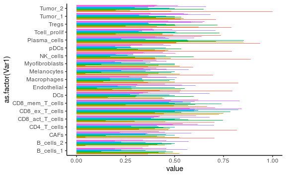

```r
predictor.dt = predictor.dt[!is.na(value)]
p.predictor = ggplot(data=predictor.dt, aes(y = value, x = as.factor(Var1)))  +
  geom_bar(aes(fill = as.factor(Var2)), stat="identity", position = position_dodge(preserve = 'single')) +
  coord_flip() +
  theme_bw() + theme(panel.border = element_blank(), panel.grid.major = element_blank(),
                     panel.grid.minor = element_blank(), axis.line = element_line(colour = "black")) +
  theme(legend.position = "none")
print(p.predictor)
```

## Evaluate the difference of ICB cohort and other cohort.

[figure not shown]

## Read ICB read count data.

```r
variable.genes.union = unique(unlist(variable.genes.list))
```

```
Error in unlist(variable.genes.list) :
  object 'variable.genes.list' not found
```

## Write dataset and run deepImmune

```r
library(avinash)
genes.curr = variable.genes.sel
icb.response.dt$label = icb.response.dt[,paste(Patient, dataset)]

for (dataset.curr in unique(icb.response.dt$dataset)) {
  icb.response.dt.curr = icb.response.dt[dataset==dataset.curr][label %in% meta.info.dt$label]

  expression.icb.sel = apply(expression.merge[match(icb.response.dt.curr$label, meta.info.dt$label),  genes.curr], 2, avinash::qnorm.array)
  expression.icb.sel[is.na(expression.icb.sel)] = 0

  icb.dataset.curr = data.table(cbind(cancertype=dataset.curr, expression.icb.sel, response=icb.response.dt.curr$Response1))
  dataset.dir = sprintf("~/project/deeplearning/icb/data/icb/scrna_transer/%s", dataset.curr)
  write.dataset(output.dir = dataset.dir, dataset = icb.dataset.curr, sample.name = icb.response.dt.curr[,paste(Patient, dataset)])
  out = sprintf("\"%s\" \"icb\" \"[1,1,1]\" \"../data/icb/scrna_transer/%s\"    1   ['all'] [0,0]", dataset.curr, dataset.curr)
  message(out)
}
```

```r
col = col1[c(1:125, seq(126,175,2), 177:300]
```

```
Error: unexpected ']' in "col = col1[c(1:125, seq(126,175,2), 177:300]"
```

```r
NA
```

## pathway enrichment of differentially expressed genes in single cell data.

```r
formula_res_scrna <- clusterProfiler::compareCluster(ENTREZID~up_or_down+type, data=diff.exp.dt[P< 1E-3][!is.na(up_or_down)], fun="clusterProfiler::enrichKEGG", organism="hsa", pvalueCutoff=0.05, universe=universe$ENTREZID)
```

[output not shown]

```r
Q
```

[output not shown]

## pathway enrichment of differentially expressed genes in bulk rnaseq data.

## combining the scRNA and bulk

```r
formula_res_combined@compareClusterResult = c(formula_res_bulk@geneClusters, formula_res_scrna@geneClusters)
```

```
Error in (function (cl, name, valueClass)  :
  assignment of an object of class “list” is not valid for @‘compareClusterResult’ in an object of class “compareClusterResult”; is(value, "data.frame") is not TRUE
```

## cytokines enrichment

```r
pheatmap(out1, cluster_cols = T,fontsize_col = 5, filename="~/Rplot2.pdf", width = 10, height = 10)
```

```
Error in hclust(d, method = method) : must have n >= 2 objects to cluster
```

## Cytokines in the bulk tumors.

```r
pheatmap(out1.bulk, cluster_cols = T,fontsize_col = 5, fontsize_row = 5, filename="~/cytokine.deg.bulk.pdf", width = 15, height = 10)
```

```
Error in hclust(d, method = method) :
  NA/NaN/Inf in foreign function call (arg 10)
```

## Combine Nir (Moshe et. al.) data to the analysis

```r
gorgan = readRDS.gz("~/liulab_home/data/single_cell/GSE139555/GSE139555_all_integrated.rds")
```

```
Error in readRDS.gz("~/liulab_home/data/single_cell/GSE139555/GSE139555_all_integrated.rds") :
  could not find function "readRDS.gz"
```